# Timeseries hell

2024-02-01

# Definition of stationarity

– no change in mean or variance.

– no systematic trend (e.g. change in the mean).

– no oscillations or seasonality.

# Random walk model

Based on the SAFS course this is the mathematical definition of a random walk

$$x_t = x_{t-1} + w_t$$

Here is some code to simluate a random walk process:

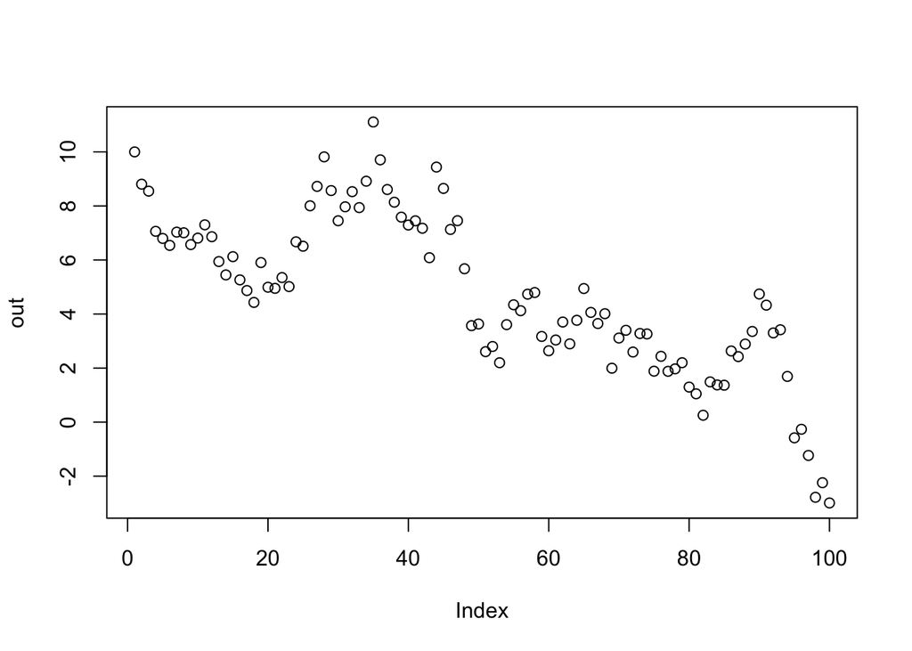

```r
n = 100
white_noise <- rnorm(100)

out <- vector(length = n)
out[1] <- 10

for(i in 2:n){
  out[i] = out[i-1] + white_noise[i]
}

plot(out)
```

Similarly, a biased random walk just has some additive influence at each time step:

$$x_t = x_{t-1} + \mu + w_t$$

The SAFS course proves that RW models are NOT stationary, but I’ll be honest I can’t really figure out logically why.

# AR(1) model

So the ar1 model is almost exactly the same as the random walk model. The only difference is that is has a phi parameter. So $w_t$ is exactly the same (just random white noise, eg. rnorm(n)), that is added to the observation in the previous time step. EXCEPT that the previous time step is now multiplied by $\phi$

$$x_t = \phi x_{t-1} + w_t$$
Here is some code to generate a ar1 time series.

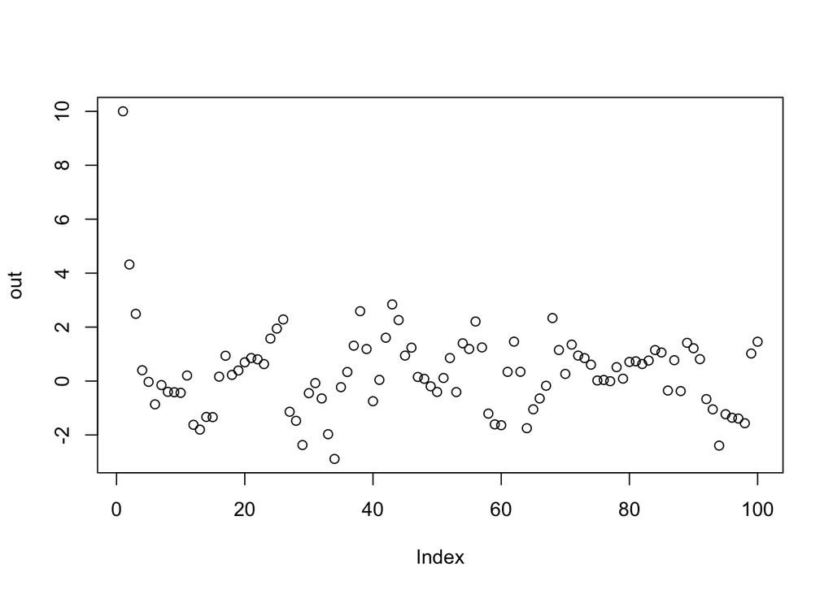

```r
n = 100
white_noise <- rnorm(100)

out <- vector(length = n)
out[1] <- 10
phi = 0.5

for(i in 2:n){
  out[i] = phi*out[i-1] + white_noise[i]
}

plot(out)
```

The SAFS course argues that a ar1 time series is only stationary if $0 < \phi < 1$. There is also something about negative $\phi$ but I didn’t follow all that.

# Random walk model with a linear trend

So if we want to generate a time series model with a linear trend we need to incorporate a slope $m$ (also refered to as drift) and an intercept $\alpha_0$. We could think of this as:

$$\begin{aligned}
\sigma_{RW} = x_{t-1} + w_t \\
\mu = \alpha_0 + mt + \sigma_{RW}\\
\end{aligned}$$
Where $w_t$ is white noise, $m$ is the slope, $t$ is an index of time (like year), and $\sigma_{RW}$ is random walk error.

We can simulate this process using the following code. And fit a simple lm regression to pull out the linear trend. We can also see that there are still autocorrelated errors by the ACF plot of the residuals.

```r
set.seed(123)
n = 100
t = 1:n
sd = 50
mean_noise = 0
white_noise <- rnorm(n, mean_noise, sd)

out <- vector()
out[1] <- 100
m = 15
a0 = 100

ts <- vector()
for(i in 2:n){
  out[i] = out[i-1] + white_noise[i]
  ts[i] = a0 + m*t[i] + out[i]
}


lm1 <- lm(ts ~ t)
summary(lm1)
```

```
##
## Call:
## lm(formula = ts ~ t)
##
## Residuals:
##     Min      1Q  Median      3Q     Max
## -204.29  -58.64  -10.76   59.63  274.07
##
## Coefficients:
##             Estimate Std. Error t value Pr(>|t|)
## (Intercept) 227.4730    19.6797   11.56   <2e-16 ***
## t            17.4655     0.3366   51.88   <2e-16 ***
## ---
## Signif. codes:  0 '***' 0.001 '**' 0.01 '*' 0.05 '.' 0.1 ' ' 1
##
## Residual standard error: 95.72 on 97 degrees of freedom
##   (1 observation deleted due to missingness)
## Multiple R-squared:  0.9652, Adjusted R-squared:  0.9649
## F-statistic:  2692 on 1 and 97 DF,  p-value: < 2.2e-16
```

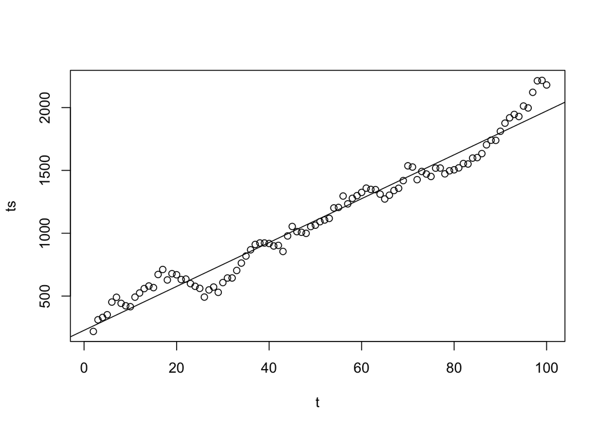

```r
plot(ts ~ t)
abline(lm1)
```

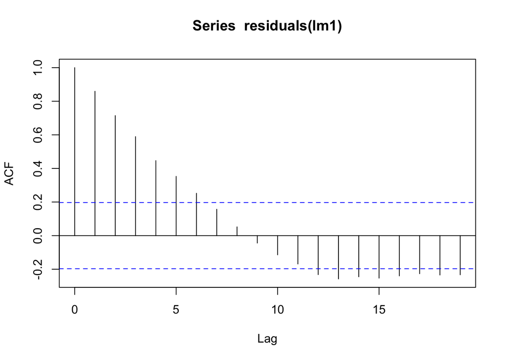

```r
acf(residuals(lm1))
```

```r
library(nlme)
df <- data.frame(ts = ts, t = t) %>% drop_na(ts)
gls_rw <- gls(ts ~ t, df, correlation = corAR1())
gls_rw
```

```
## Generalized least squares fit by REML
##   Model: ts ~ t
##   Data: df
##   Log-restricted-likelihood: -511.0574
##
## Coefficients:
## (Intercept)           t
##   171.60517    18.98194
##
## Correlation Structure: AR(1)
##  Formula: ~1
##  Parameter estimate(s):
##       Phi
## 0.9469103
## Degrees of freedom: 99 total; 97 residual
## Residual standard error: 140.4871
```

When we use gls() we can see that $\phi$ is close to 1, which makes sense because a random walk is just a ar1(), where $\phi \to 1$.

# AR1 model with a linear trend

So if we use similar logic we could simulate a ar1 model with a linear trend.

$$\begin{aligned}
\sigma_{RW} = \phi x_{t-1} + w_t \\
\mu = \alpha_0 + mt + \sigma_{RW}
\end{aligned}$$

Where again $w_t$ is white noise, $m$ is the slope, $t$ is an index of time (like year), and $\sigma_{RW}$ is random walk error. However, the difference is that now we have the parameter $phi$.

We can simulate some data to look at the difference:

```r
set.seed(123)
n = 100
t = 1:n
sd = 50
mean_noise = 0
white_noise <- rnorm(n, mean_noise, sd)

out <- vector()
out[1] <- 100
m = 15
a0 = 100
phi = 0.5

ts <- vector()
for(i in 2:n){
  out[i] = phi*out[i-1] + white_noise[i]
  ts[i] = a0 + m*t[i] + out[i]
}


lm1 <- lm(ts ~ t)
summary(lm1)
```

```
##
## Call:
## lm(formula = ts ~ t)
##
## Residuals:
##      Min       1Q   Median       3Q      Max
## -124.479  -35.144   -3.003   35.555  112.834
##
## Coefficients:
##             Estimate Std. Error t value Pr(>|t|)
## (Intercept) 101.4491    10.6709   9.507 1.56e-15 ***
## t            15.1864     0.1825  83.199  < 2e-16 ***
## ---
## Signif. codes:  0 '***' 0.001 '**' 0.01 '*' 0.05 '.' 0.1 ' ' 1
##
## Residual standard error: 51.9 on 97 degrees of freedom
##   (1 observation deleted due to missingness)
## Multiple R-squared:  0.9862, Adjusted R-squared:  0.986
## F-statistic:  6922 on 1 and 97 DF,  p-value: < 2.2e-16
```

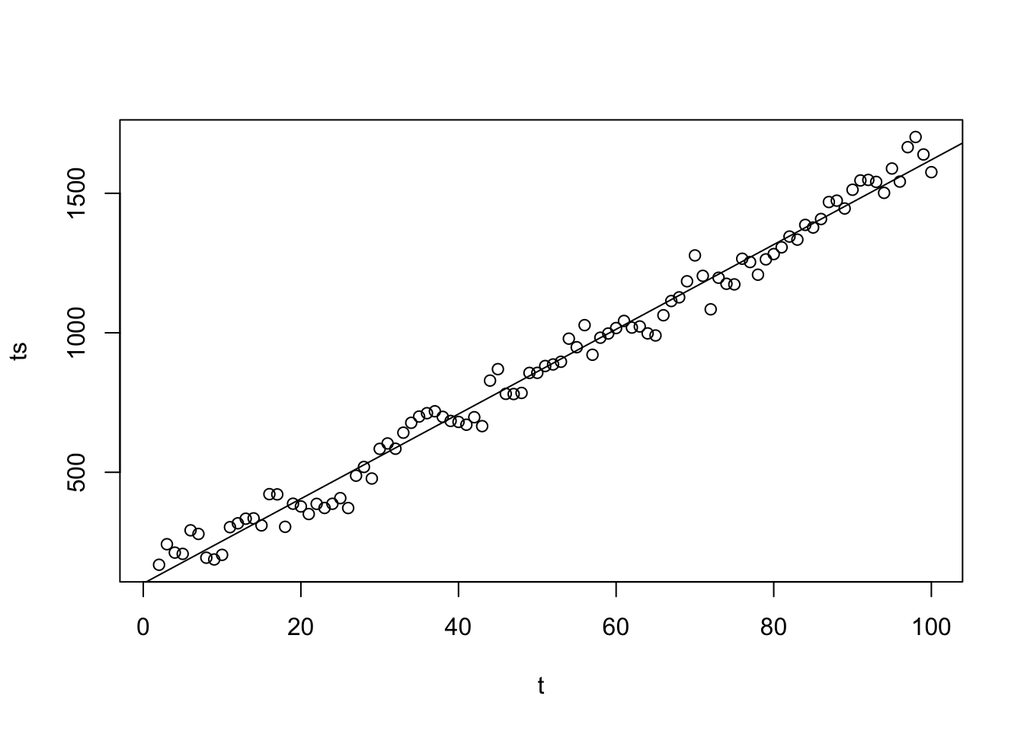

```r
plot(ts ~ t)
abline(lm1)
```

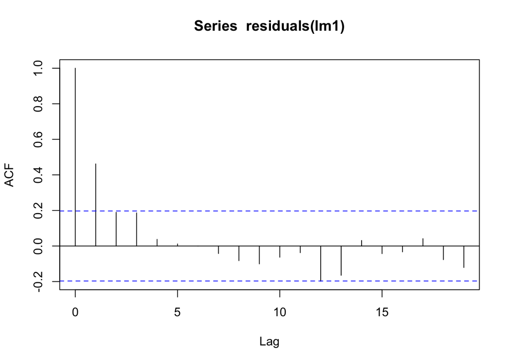

```r
acf(residuals(lm1))
```

```r
df <- data.frame(ts = ts, t = t) %>% drop_na(ts)
library(nlme)

gls1 <- gls(ts ~ t, df, correlation = nlme::corAR1())
summary(gls1)
```

```
## Generalized least squares fit by REML
##   Model: ts ~ t
##   Data: df
##        AIC      BIC   logLik
##   1039.428 1049.727 -515.714
##
## Correlation Structure: AR(1)
##  Formula: ~1
##  Parameter estimate(s):
##       Phi
## 0.4938776
##
## Coefficients:
##                 Value Std.Error  t-value p-value
## (Intercept) 103.77250 18.221083  5.69519       0
## t            15.13934  0.310209 48.80372       0
##
##  Correlation:
##   (Intr)
## t -0.868
##
## Standardized residuals:
##         Min          Q1         Med          Q3         Max
## -2.37544389 -0.65981071 -0.07731816  0.68854888  2.16317661
##
## Residual standard error: 52.86613
## Degrees of freedom: 99 total; 97 residual
```

So when you look at the output from the gls1 which is just a simple linear regression with ar1 correlated errors we see that we can recover the value of $phi$.

# Getting back to the original question:

Ok, so Andrew I’m pretty sure what you were asking was are projections/simulations from a ar1 model more/less likely to show a trend vs. jump around some averagae value (be relatively stable). So I think after playing around with this a bit, that the answer is that neither an ar1 or a rw model is more likely to show a trend. Like you mentioned on slack, as $phi$ –> 1 an ar1 model approaches a rw model. So the way I see it there has to be some underlying process, independent of the ar1 or rw process that is causing a linear (or nonlinear) trend through time.